# Exam 3 - Skills Test

Jacob Janke

2026-04-21

# Task 1: Load and Clean FacultySalaries_1995.csv

First, I’ll load the necessary libraries and import the data.

```r
library(ggplot2)
library(dplyr)
library(tidyr)
library(readr)
library(broom)
```

```r
# Load the faculty salaries data
faculty <- read.csv("FacultySalaries_1995.csv")

# View the structure
head(faculty)
```

```
##   FedID                  UnivName State Tier AvgFullProfSalary
## 1  1061 Alaska Pacific University    AK  IIB               454
## 2  1063     Univ.Alaska-Fairbanks    AK    I               686
## 3  1065     Univ.Alaska-Southeast    AK  IIA               533
## 4 11462     Univ.Alaska-Anchorage    AK  IIA               612
## 5  1002 Alabama Agri.&Mech. Univ.    AL  IIA               442
## 6  1004  University of Montevallo    AL  IIA               441
##   AvgAssocProfSalary AvgAssistProfSalary AvgProfSalaryAll AvgFullProfComp
## 1                382                 362              382             567
## 2                560                 432              508             914
## 3                494                 329              415             716
## 4                507                 414              498             825
## 5                369                 310              350             530
## 6                385                 310              388             542
##   AvgAssocProfComp AvgAssistProfComp AvgProfCompAll NumFullProfs NumAssocProfs
## 1              485               471            487            6            11
## 2              753               572            677           74           125
## 3              663               442            559            9            26
## 4              681               557            670          115           124
## 5              444               376            423           59            77
## 6              473               383            477           57            33
##   NumAssistProfs NumInstructors NumFacultyAll
## 1              9              4            32
## 2            118             40           404
## 3             20              9            70
## 4            101             21           392
## 5            102             24           262
## 6             35              2           127
```

Now I need to tidy this data. The issue is that we have separate columns for different ranks (Full, Assoc, Assistant) but we need them in a long format with Rank as a variable.

```r
# Tidy the data by pivoting the salary columns
faculty_tidy <- faculty %>%
  select(State, Tier, AvgFullProfSalary, AvgAssocProfSalary, AvgAssistProfSalary) %>%
  pivot_longer(
    cols = starts_with("Avg"),
    names_to = "Rank",
    values_to = "Salary"
  ) %>%
  mutate(
    Rank = case_when(
      Rank == "AvgFullProfSalary" ~ "Full",
      Rank == "AvgAssocProfSalary" ~ "Associate",
      Rank == "AvgAssistProfSalary" ~ "Assistant"
    ),
    Rank = factor(Rank, levels = c("Assistant", "Associate", "Full"))
  )

head(faculty_tidy)
```

```
## # A tibble: 6 × 4
##   State Tier  Rank      Salary
##   <chr> <chr> <fct>      <int>
## 1 AK    IIB   Full         454
## 2 AK    IIB   Associate    382
## 3 AK    IIB   Assistant    362
## 4 AK    I     Full         686
## 5 AK    I     Associate    560
## 6 AK    I     Assistant    432
```

Now I’ll recreate the graph from Fig1.png:

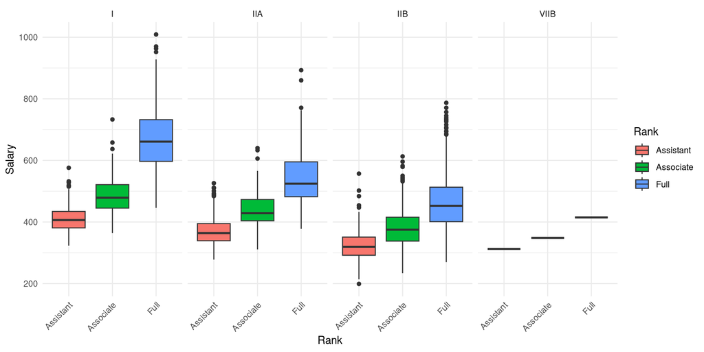

```r
ggplot(faculty_tidy, aes(x = Rank, y = Salary, fill = Rank)) +
  geom_boxplot() +
  facet_grid(~ Tier) +
  labs(
    x = "Rank",
    y = "Salary"
  ) +
  theme_minimal() +
  theme(axis.text.x = element_text(angle = 45, hjust = 1))
```

# Task 2: Build ANOVA Model

Building an ANOVA model to test the influence of State, Tier, and Rank on Salary without interactions:

```r
# Build the ANOVA model
anova_model <- aov(Salary ~ State + Tier + Rank, data = faculty_tidy)

# Display the summary
summary(anova_model)
```

```
##               Df   Sum Sq Mean Sq F value Pr(>F)
## State         51  5682396  111420   30.66 <2e-16 ***
## Tier           2  7072361 3536180  972.96 <2e-16 ***
## Rank           2 16529771 8264885 2274.04 <2e-16 ***
## Residuals   3299 11990072    3634
## ---
## Signif. codes:  0 '***' 0.001 '**' 0.01 '*' 0.05 '.' 0.1 ' ' 1
## 128 observations deleted due to missingness
```

The ANOVA results show that State, Tier, and Rank all have significant effects on faculty salaries.

# Task 3: Load and Tidy Juniper_Oils.csv

Now loading the Juniper oils dataset:

```r
# Load the data
juniper <- read.csv("Juniper_Oils.csv")

# View the structure
head(juniper)
```

```
##       SampleID     Project Amplicon          Tree_Species BurnYear Latitude
## 1 LOG-16S-SL12 JuniperLogs      16S Juniperus osteosperma     2018  41.5719
## 2 LOG-16S-SL11 JuniperLogs      16S Juniperus osteosperma     2017  40.9202
## 3  LOG-16S-CC5 JuniperLogs      16S Juniperus osteosperma     2016  37.5799
## 4  LOG-16S-SL9 JuniperLogs      16S Juniperus osteosperma     2014  39.9422
## 5  LOG-16S-SL8 JuniperLogs      16S Juniperus osteosperma     2013  41.5335
## 6  LOG-16S-SL7 JuniperLogs      16S Juniperus osteosperma     2012  40.8316
##   Longitude Field_Office BLM_Fire_Name Tracking_Number alpha.pinene para.cymene
## 1 -113.7488  Salt_Lake_3         Ridge    #5276 (2018)          0.6         0.4
## 2 -113.0017  Salt_Lake_2          Knob    #5275 (2017)          1.4         0.3
## 3 -113.0851   Cedar_City   Hicks Creek    #5274 (2016)          0.2         1.1
## 4 -112.7181  Salt_Lake_4     Lion Peak    #5273 (2014)          0.3         0.1
## 5 -113.7096  Salt_Lake_3    Playground    #5272 (2013)          0.1         0.1
## 6 -112.4833  Salt_Lake_2 Shanty Canyon    #5271 (2012)          0.0         0.1
##   alpha.terpineol cedr.9.ene alpha.cedrene beta.cedrene cis.thujopsene
```

[output cut: 41 more lines]

The data needs to be tidied - we need to convert the chemical compound columns into a long format:

```r
# List of chemical compounds (as they appear in the data with dots)
chemicals_in_data <- c("alpha.pinene","para.cymene","alpha.terpineol","cedr.9.ene",
                       "alpha.cedrene","beta.cedrene","cis.thujopsene","alpha.himachalene",
                       "beta.chamigrene","cuparene","compound.1","alpha.chamigrene",
                       "widdrol","cedrol","beta.acorenol","alpha.acorenol",
                       "gamma.eudesmol","beta.eudesmol","alpha.eudesmol","cedr.8.en.13.ol",
                       "cedr.8.en.15.ol","compound.2","thujopsenal")

# Original chemical names with hyphens for display
chemicals_display <- c("alpha-pinene","para-cymene","alpha-terpineol","cedr-9-ene",
                       "alpha-cedrene","beta-cedrene","cis-thujopsene","alpha-himachalene",
                       "beta-chamigrene","cuparene","compound 1","alpha-chamigrene",
                       "widdrol","cedrol","beta-acorenol","alpha-acorenol",
                       "gamma-eudesmol","beta-eudesmol","alpha-eudesmol","cedr-8-en-13-ol",
                       "cedr-8-en-15-ol","compound 2","thujopsenal")

# Create a named vector for mapping
chem_mapping <- setNames(chemicals_display, chemicals_in_data)

# Tidy the data
juniper_tidy <- juniper %>%
  select(YearsSinceBurn, all_of(chemicals_in_data)) %>%
  pivot_longer(
    cols = all_of(chemicals_in_data),
    names_to = "ChemicalID",
    values_to = "Concentration"
  ) %>%
  mutate(ChemicalID = chem_mapping[ChemicalID])

head(juniper_tidy)
```

```
## # A tibble: 6 × 3
##   YearsSinceBurn ChemicalID      Concentration
##            <int> <chr>                   <dbl>
## 1              2 alpha-pinene              0.6
## 2              2 para-cymene               0.4
## 3              2 alpha-terpineol           2.3
## 4              2 cedr-9-ene                0.2
## 5              2 alpha-cedrene             1.9
## 6              2 beta-cedrene              1.2
```

# Task 4: Create Graph of YearsSinceBurn vs Concentration

Creating a faceted graph showing the relationship between years since burn and chemical concentrations:

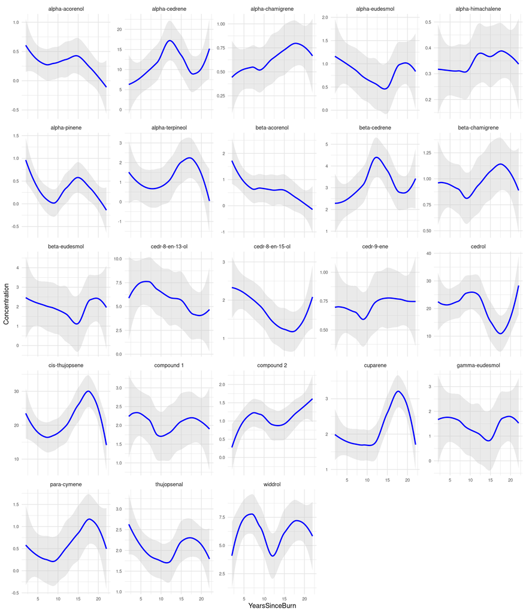

```r
ggplot(juniper_tidy, aes(x = YearsSinceBurn, y = Concentration)) +
  geom_smooth(method = "loess", se = TRUE, color = "blue", fill = "grey80") +
  facet_wrap(~ ChemicalID, scales = "free_y", ncol = 5) +
  labs(
    x = "YearsSinceBurn",
    y = "Concentration"
  ) +
  theme_minimal() +
  theme(
    strip.text = element_text(size = 9),
    axis.text = element_text(size = 7),
    panel.grid = element_line(color = "grey90")
  )
```

# Task 5: GLM Model to Find Significant Chemicals

Building a generalized linear model to test which chemicals are significantly affected by years since burn:

```r
# Build a GLM model with interaction between ChemicalID and YearsSinceBurn
glm_model <- lm(Concentration ~ ChemicalID * YearsSinceBurn, data = juniper_tidy)

# Use broom to tidy the model output
glm_tidy <- tidy(glm_model)

# Find chemicals with significant interaction with YearsSinceBurn
significant_interactions <- glm_tidy %>%
  filter(grepl(":YearsSinceBurn", term) & p.value < 0.05)

# Extract the chemical names from significant interactions
sig_chem_names <- gsub("ChemicalID", "",
                       gsub(":YearsSinceBurn", "", significant_interactions$term))

# Get all terms (main effects and interactions) for these significant chemicals
significant_chemicals <- glm_tidy %>%
  filter(
    term %in% paste0("ChemicalID", sig_chem_names) |
    term %in% paste0("ChemicalID", sig_chem_names, ":YearsSinceBurn")
  ) %>%
  mutate(term = gsub("ChemicalID", "", term)) %>%
  arrange(p.value) %>%
  select(term, estimate, std.error, statistic, p.value)

# Display the significant chemicals
print(significant_chemicals, n = Inf)
```

```
## # A tibble: 2 × 5
##   term                          estimate std.error statistic  p.value
##   <chr>                            <dbl>     <dbl>     <dbl>    <dbl>
## 1 cis-thujopsene                  17.3       1.93       8.95 2.93e-18
## 2 cis-thujopsene:YearsSinceBurn    0.332     0.141      2.35 1.90e- 2
```

The table above shows the chemicals that have concentrations significantly affected by the number of years since the burn event. These chemicals show either significant increases or decreases in concentration over time, as indicated by their coefficient estimates and p-values less than 0.05.

# Summary

This exam covered:

1. **Data tidying**: Transformed the FacultySalaries dataset from wide to long format to enable proper analysis and visualization
2. **ANOVA modeling**: Built a model to test the effects of State, Tier, and Rank on faculty salaries
3. **Data wrangling**: Tidied the Juniper oils dataset by converting multiple chemical columns into a long format
4. **Data visualization**: Created faceted plots to visualize trends in chemical concentrations over time
5. **Statistical modeling**: Used GLM to identify which chemicals show significant changes in concentration based on years since burn

All analyses were completed using relative file paths within the R project structure.